# Race, Part 2: From the Drug War to the ACA

POSC 459 — Social Welfare Politics and Policy · Week 13, Monday 16 November 2026

*Accessible text version of the Week 13 Monday slides — same content in linear order, with no slide-scaling container. Each image carries a text description. Reading: Michener 2020, “Race, Politics, and the Affordable Care Act.”*

[figure not shown]

*Michener 2020, “Race, Politics, and the Affordable Care Act”*

*Photo: ACA signing, March 23, 2010 · Lawrence Jackson, White House · CC BY 2.0*

## Today

1. Last week in one picture
2. Your question: the 1980s
3. Michener: what the ACA promised
4. Medicaid after 2012
5. Waivers and work requirements
6. Beyond expansion
7. Design or politics?

## Last week in one picture

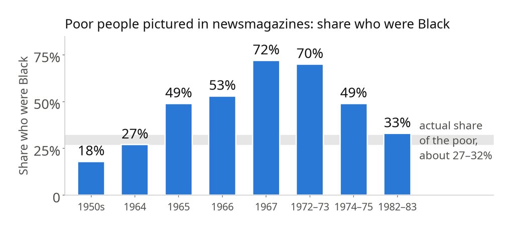

Howard, also last week: states with more minority residents paid lower benefits

*Chart: Gilens 1999, pp. 114, 117, 123–24, 126 · Howard 2007, pp. 187–91*

## Your question: the 1980s

- Newsmagazine photos of the poor: **33%** Black in 1982–83, “high” again by 1988–92
- Photos in “underclass” stories: **100%** Black
- July 1986: **74** network news segments on crack
- 1989 *Washington Post* column: cocaine-exposed babies a “bio-underclass”
- 2001 medical review: “no convincing evidence” of harm specific to cocaine

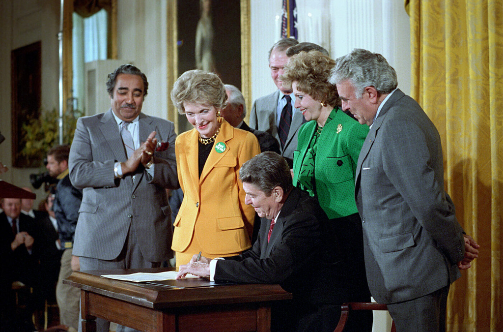

*Signing the Anti-Drug Abuse Act, Oct. 27, 1986 · White House photo, National Archives*

*Gilens, pp. 126, 129–31 · USSC 1995, pp. 122–23 · Washington Post, July 30, 1989 · Frank et al., JAMA, 2001*

## 1986 and 1988: 100 to 1

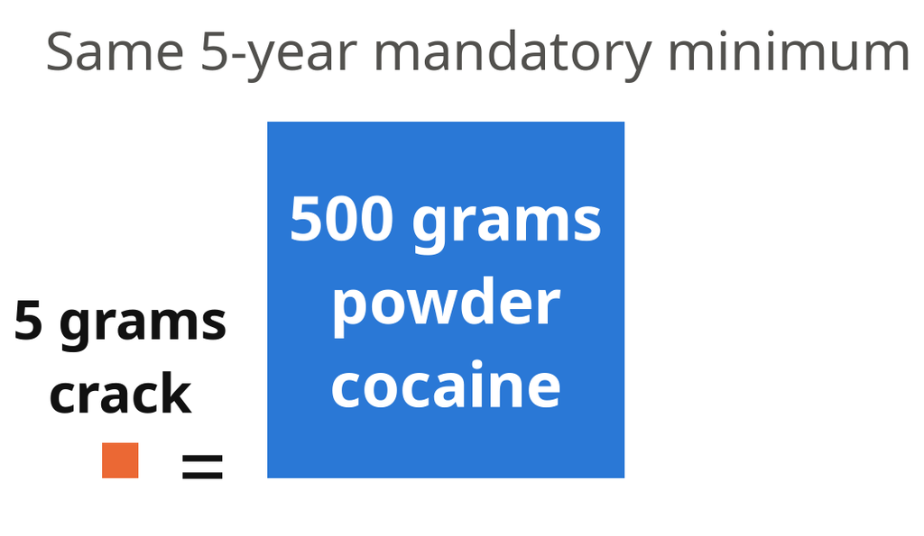

**1986:** 5 g crack = 500 g powder → 5-year minimum

**1988:** possessing 5+ g crack, first offense → 5 years

Passed with no committee hearings

**2010:** Congress cut the ratio to about 18 to 1

*Pub. L. 99-570, § 1002; Pub. L. 100-690, § 6371; Pub. L. 111-220 · USSC 1995, 1997, 2002, 2015*

## Who was arrested, who was sentenced

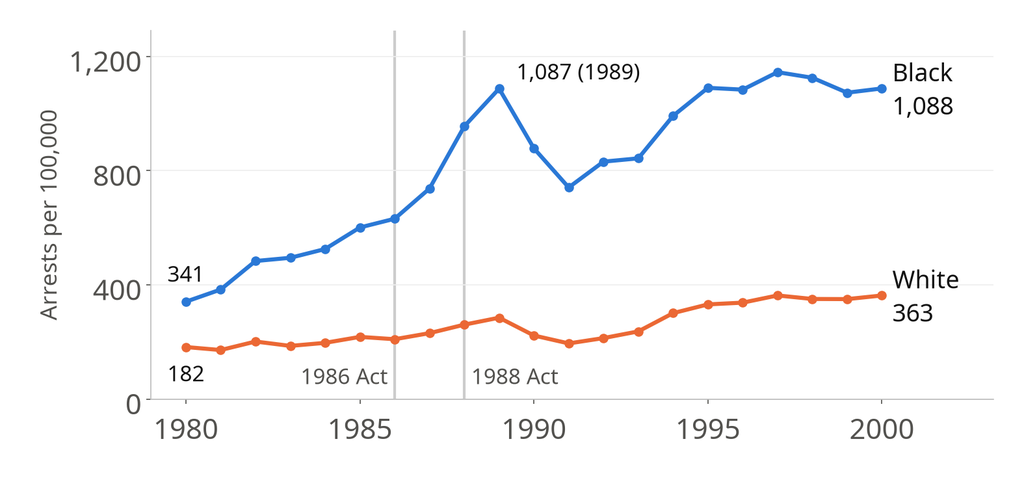

Who used crack (1991 national survey): **52%** white, **38%** Black

Who was sentenced for it (federal courts, FY1992): **91.5%** Black

*BJS, Arrest in the United States, 1980–2009, fig. 40 · USSC 1995, pp. 38–39 · USSC 1992 Annual Report, table 31*

## 1996: a drug record and the safety net

- 1996 welfare law, § 115
- Drug felony conviction → no cash aid (TANF), no food stamps (SNAP), for life
- A state may opt out or limit the ban
- SNAP today: only **South Carolina** keeps the full ban
- TANF: about **7** states still do (2022–23 counts)

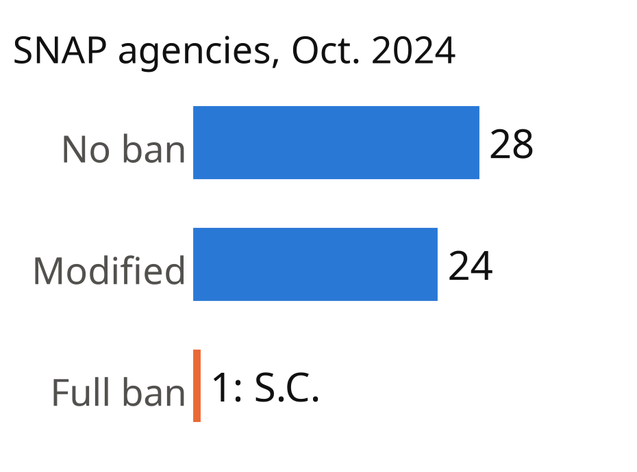

*USDA, SNAP State Options Report, 17th ed., p. 16*

*Pub. L. 104-193, § 115; 21 U.S.C. 862a · USDA, SNAP State Options Report, 17th ed., p. 16 · CRS R42394 · GAO-05-238*

## Michener: policy and politics

The ACA was written to shrink racial disparities

“politics can undermine the steps necessary to do so”

**Two cases:** Medicaid expansion · race-specific provisions

*Michener 2020, JHPPL 45(4), pp. 547–49*

## The promise, and the first results

The law’s own text: “disparities” **34** times · “race” or “racial” **33** times

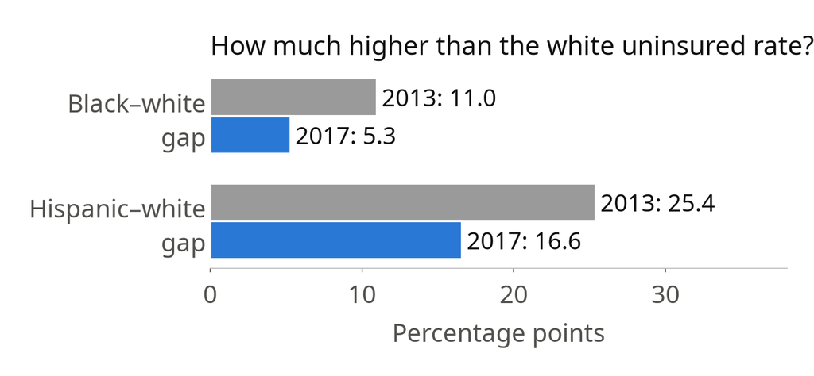

Both gaps shrank, 2013–17. Then progress stalled.

*Michener, p. 548, citing Chaudry, Jackson, and Glied 2019*

## Medicaid expansion, as written

|  | The ACA as passed in 2010 |
| --- | --- |
| Who is covered | anyone with income up to **138%** of the poverty line |
| Carrot | Washington pays **100%**, 2014–16; **90%** by 2020 |
| Stick | a state that refuses loses **all** its federal Medicaid money |
| Intended result | the same coverage floor in every state |

*Michener, pp. 549–50 · about 20% of Medicaid enrollees Black, 30% Latino (p. 550)*

## 2012: *NFIB v. Sebelius*

- The Court: the stick is “coercive”
- Expansion becomes each state’s choice
- Many states said no
- Mostly by party, “particularly in the South”

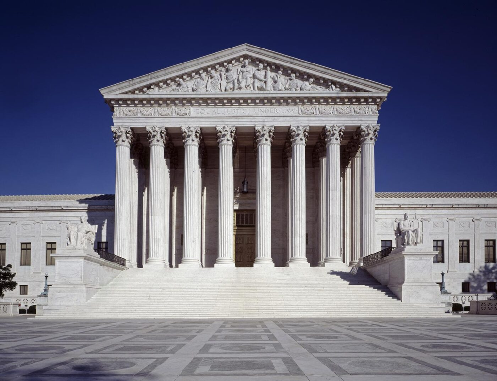

*Carol M. Highsmith, Library of Congress*

*Michener, p. 550 · 567 U.S. 519 (2012)*

## Who expanded: 2020 and now

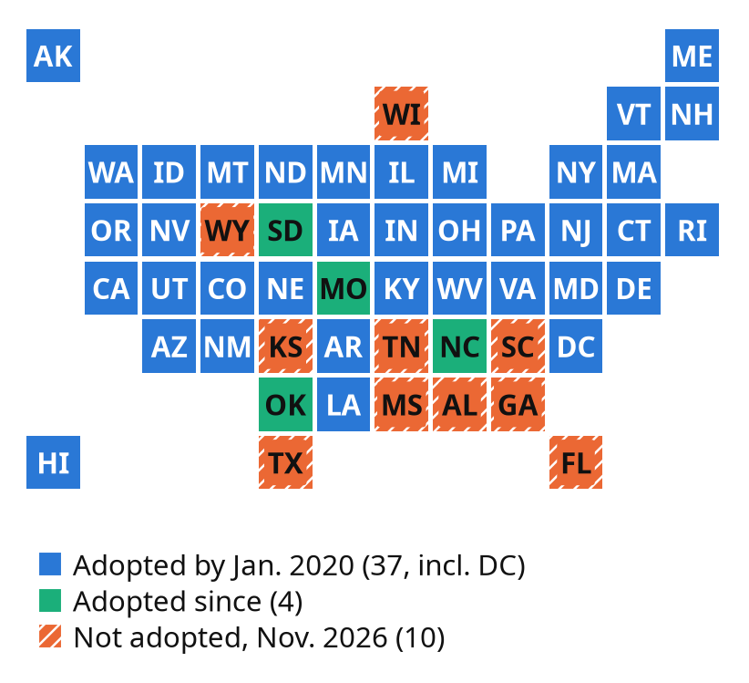

Jan. 2020: **14** states had not expanded

Since then: Missouri, Oklahoma, South Dakota by ballot measure; North Carolina by legislature

Still not expanded: **10**, 7 of them in the South

*KFF, Status of State Medicaid Expansion Decisions, Jan. 10, 2020 and Nov. 6, 2026 · Michener, fig. 1, p. 552*

## Who falls in the coverage gap

**Coverage gap:** adults in non-expansion states who earn too little for marketplace subsidies and can’t get Medicaid

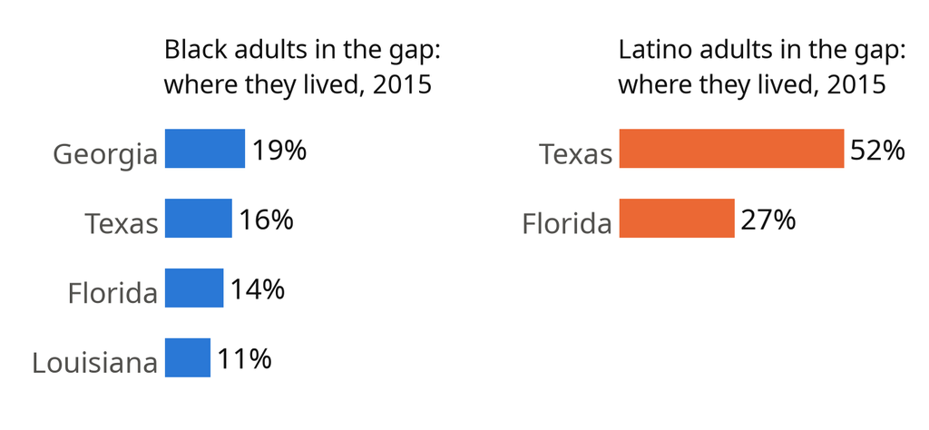

*Michener, p. 551, citing Artiga, Damico, and Garfield 2015 (KFF)*

## Why did states refuse? Michener’s evidence

- States with more racial resentment resisted expansion more
- State decisions followed **white** residents’ opinion, not nonwhite residents’
- Larger Black population + low white support → less likely to expand
- Federalism: “one of the chief bulwarks of racial domination”

*Michener, pp. 550–51 · Lanford and Quadagno 2015; Grogan and Park 2017; Brown 2003, quoted*

## Waivers: Arkansas Works, 2018

- Section 1115 waiver: federal permission for a state to change Medicaid’s rules
- Arkansas: expansion adults under 50 must report **80 hours** a month
- Hours of work, school, or community service
- In 7 months: **18,000+** people lost coverage
- Result: coverage down, uninsured up, employment unchanged

*Michener, pp. 554–55 · Wagner and Schubel 2019; Sommers et al. 2019*

## Who carries the loss

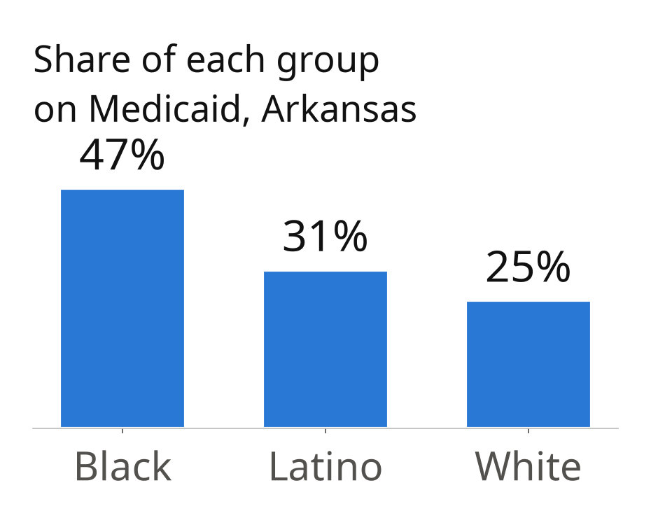

Black Arkansans: **15%** of residents, **26%** of Medicaid enrollees

A work rule is harder to meet with a criminal record and hiring bias

The link back to 1986 and 1988: a drug conviction is a record

*Michener, pp. 555–57 · Pager 2008, cited*

## Beyond expansion: three race-specific provisions

| Provision | What it did | What happened |
| --- | --- | --- |
| §4302: data by race | HHS must collect and report it | **15** federal rules used it, mostly 2012–16 · only **3** from 2017 to 2020 |
| Workforce diversity | train and diversify health workers | Congress refused **$3 million** for a commission · FY2020 budget proposed cutting **$88 million** in diversity training |
| §1557: nondiscrimination | notices in each state’s top 15 languages | 2019 rewrite dropped mailed notices · **~156,000** public comments |

Each one depended on who ran the agency or what Congress funded

*Michener, table 1, p. 558; pp. 557–61 · King 2017, quoted*

## Michener’s conclusion

“the distance between policy intentions and policy outcomes”

Where politics got in: courts · states · waivers · appointees · appropriations

*Michener, p. 561*

## Design or politics?

Michener: the law aimed at equity; **politics** undid it

Wednesday, Mettler: in 1935 the **design** did the sorting

**With a partner, 4 minutes:**

1. Decide: did the ACA’s racial coverage gap come from how the law was designed, or from the politics after it passed?
2. Find one page in Michener that supports your answer.
3. Be ready to give both, the answer and the page.

*Sets up Paper 5*

## Wednesday and Friday

**Wed 11/18:** Mettler, *Dividing Citizens*, chs. 1, 5, 6

**Fri 11/20, 11:59 p.m.:** Paper 5

**The Paper 5 question:** do Mettler and Michener describe the same mechanism, or two that only look alike?

*Mechanism = the way a policy ends up sorting people*

**11/23–27:** Thanksgiving, no class

## By 2:15 you should be able to say

The picture of the poor followed sympathy, not facts

1986 and 1988: crack punished 100 to 1; most people sentenced were Black

1996: a drug felony could end food and cash aid

ACA: written for equity, unwound by politics

*Sebelius* let states opt out; the coverage gap is Southern, Black, and Latino

Design or politics: how would you tell?